# Cook Inlet 2021 analysis

### Read in fish catch data

| station_number | Year | region | fishing_method | Lat | Lon | trawl_ave_net_depth_m | trawl_distance_towed_m | common_name | SumOfcount | genus_name | species_name |
| --- | --- | --- | --- | --- | --- | --- | --- | --- | --- | --- | --- |
| 202117601 | 2021 | Prince William Sound | modified herring trawl | 60.19216 | -148.1839 | NA | NA | Arrowtooth flounder | 2 | Atheresthes | stomias |
| 202117601 | 2021 | Prince William Sound | modified herring trawl | 60.19216 | -148.1839 | NA | NA | Big skate | 1 | Beringraja | binoculata |
| 202117601 | 2021 | Prince William Sound | modified herring trawl | 60.19216 | -148.1839 | NA | NA | Eulachon | 3 | Thaleichthys | pacificus |
| 202117601 | 2021 | Prince William Sound | modified herring trawl | 60.19216 | -148.1839 | NA | NA | Flathead sole | 21 | Hippoglossoides | elassodon |
| 202117601 | 2021 | Prince William Sound | modified herring trawl | 60.19216 | -148.1839 | NA | NA | Great sculpin | 1 | Myoxocephalus | polyacanthocephalus |
| 202117601 | 2021 | Prince William Sound | modified herring trawl | 60.19216 | -148.1839 | NA | NA | Rex sole | 1 | Glyptocephalus | zachirus |

Summarize the catch per station - just looking at data from Cook Inlet for now.

| station_number | Year | region | fishing_method | Lat | Lon | trawl_ave_net_depth_m | trawl_distance_towed_m | common_name | SumOfcount | genus_name | species_name |
| --- | --- | --- | --- | --- | --- | --- | --- | --- | --- | --- | --- |
| 2021105001 | 2021 | Cook Inlet | modified herring trawl | 60.02233 | -152.5408 | 14.82 | 1.025313 | Pacific sand lance | 200 | Ammodytes | personatus |
| 2021105001 | 2021 | Cook Inlet | modified herring trawl | 60.02233 | -152.5408 | 14.82 | 1.025313 | Pink salmon (humpback) | 7 | Oncorhynchus | gorbuscha |
| 2021105001 | 2021 | Cook Inlet | modified herring trawl | 60.02233 | -152.5408 | 14.82 | 1.025313 | Snake prickleback | 1 | Lumpenus | sagitta |
| 2021122001 | 2021 | Cook Inlet | modified herring trawl | 60.16977 | -152.3031 | 35.21 | 3.782352 | Capelin | 2 | Mallotus | catervarius |
| 2021122001 | 2021 | Cook Inlet | modified herring trawl | 60.16977 | -152.3031 | 35.21 | 3.782352 | Crangon shrimp | 9 | NA | NA |
| 2021122001 | 2021 | Cook Inlet | modified herring trawl | 60.16977 | -152.3031 | 35.21 | 3.782352 | Euphausiid UNID | NA | Euphausiacea (order) | NA |

Some summary basics? How many total species, what are the dominant species, etc.

| station_number | common_name | genus_name | species_name | SumOfcount |
| --- | --- | --- | --- | --- |
| 2021126001 | Pink shrimp | NA | NA | 120 |
| 2021122001 | Pink shrimp | NA | NA | 61 |
| 2021126001 | Crangon shrimp | NA | NA | 23 |
| 2021122001 | Crangon shrimp | NA | NA | 9 |
| 2021122001 | Mysid | NA | NA | NA |
| 2021223001 | Crab UNID | NA | NA | NA |

Okay, actually, not that many and mostly things we don’t detect with MiFish. Let’s ignore those for now.

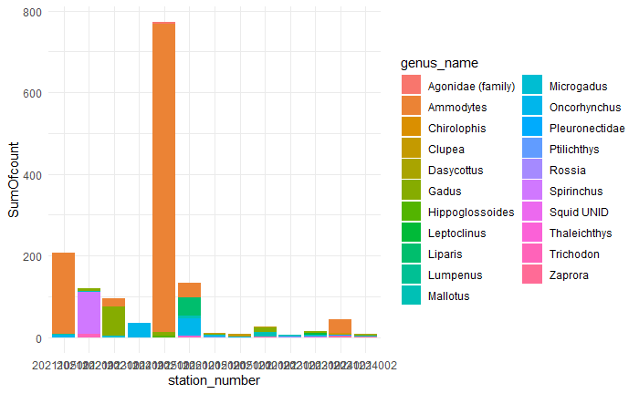

```r
cook.catch.df <- cook.catch %>%
   filter(!is.na(genus_name), SumOfcount > 0, common_name != "Squid UNID", species_name != "Pacifica") %>%
    select(station_number, common_name, genus_name, species_name, SumOfcount)  %>%
  ungroup() %>%
  mutate(family = ifelse(str_detect(genus_name, "(family)"), genus_name, NA)) %>%
  mutate(family = ifelse(genus_name == "Pleuronectidae", "Pleuronectidae", family)) %>%
    mutate(genus_name = ifelse(!is.na(family), NA, genus_name)) %>%
      mutate(family = ifelse(genus_name %in% c("Gadus", "Microgadus"), "Gadidae", family)) %>%
        mutate(family = ifelse(genus_name %in% c("Ammodytes"), "Ammodytidae", family)) %>%
          mutate(family = ifelse(genus_name %in% c("Spirinchus", "Mallotus"), "Osmeridae", family)) %>%
            mutate(family = ifelse(genus_name %in% c("Spirinchus", "Mallotus", "Thaleichthys"), "Osmeridae", family)) %>%
              mutate(family = ifelse(genus_name %in% c("Clupea"), "Clupeidae", family)) %>%
                mutate(family = ifelse(genus_name %in% c("Hippoglossoides"), "Pleuronectidae", family)) %>%
                  mutate(family = ifelse(genus_name %in% c("Oncorhynchus"), "Salmonidae", family)) %>%
                    mutate(family = ifelse(genus_name %in% c("Leptoclinus", "Lumpenus"), "Lumpenidae", family)) %>%
                      mutate(family = ifelse(genus_name %in% c("Trichodon"), "Trichodontidae", family)) %>%
                        mutate(family = ifelse(genus_name %in% c("Liparis"), "Liparidae", family)) %>%
                          mutate(family = ifelse(genus_name %in% c("Zaprora"), "Zaproridae", family)) %>%

    unite(3:4, col = "species", sep = "_", remove = F) %>%
    unique() %>%
  mutate(species = ifelse(species == "NA_NA", NA, species))


cook.catch.df %>%
  select(-station_number, -SumOfcount) %>%
  unique()
```

| common_name | species | genus_name | species_name | family |
| --- | --- | --- | --- | --- |
| Pacific sand lance | Ammodytes_personatus | Ammodytes | personatus | Ammodytidae |
| Pink salmon (humpback) | Oncorhynchus_gorbuscha | Oncorhynchus | gorbuscha | Salmonidae |
| Snake prickleback | Lumpenus_sagitta | Lumpenus | sagitta | Lumpenidae |
| Capelin | Mallotus_catervarius | Mallotus | catervarius | Osmeridae |
| Longfin smelt | Spirinchus_thaleichthys | Spirinchus | thaleichthys | Osmeridae |
| Pacific sandfish | Trichodon_trichodon | Trichodon | trichodon | Trichodontidae |
| Walleye pollock | Gadus_chalcogrammus | Gadus | chalcogrammus | Gadidae |
| Pacific cod | Gadus_macrocephalus | Gadus | macrocephalus | Gadidae |
| Pacific tomcod | Microgadus_proximus | Microgadus | proximus | Gadidae |
| Flathead sole | Hippoglossoides_elassodon | Hippoglossoides | elassodon | Pleuronectidae |

[output cut: 10 more lines]

Organize the eDNA data to merge based on species resolution?

```r
cook.edna <- rep.control.filtered.df %>%
  filter(`Sample Label` == "Cook Inlet") %>% # now take the mean reads per taxon across the replicates
  rename(station_number = `Sample Code`) %>%
  filter(reads > 0) %>%
  group_by(station_number, taxon, depth) %>%
  summarise(mean_reads = mean(reads))
```

```r
cook.edna %>%
  ungroup() %>%
  select(taxon) %>%
  unique()
```

| taxon |
| --- |
| Ammodytidae |
| Atheresthes |
| Gadidae |
| Hemilepidotus |
| Oncorhynchus |
| Osmeridae |
| Anoplarchus |
| Lycodes |
| Mallotus_villosus |
| Trichodon_trichodon |

[output cut: 17 more lines]

```r
NA
```

only 27 unique taxa - which overlap with the trawl?

| station_number | common_name | species | genus_name | species_name | SumOfcount | family |
| --- | --- | --- | --- | --- | --- | --- |
| 2021105001 | Pacific sand lance | Ammodytes_personatus | Ammodytes | personatus | 200 | Ammodytidae |
| 2021105001 | Pink salmon (humpback) | Oncorhynchus_gorbuscha | Oncorhynchus | gorbuscha | 7 | Salmonidae |
| 2021105001 | Snake prickleback | Lumpenus_sagitta | Lumpenus | sagitta | 1 | Lumpenidae |
| 2021122001 | Capelin | Mallotus_catervarius | Mallotus | catervarius | 2 | Osmeridae |
| 2021122001 | Longfin smelt | Spirinchus_thaleichthys | Spirinchus | thaleichthys | 103 | Osmeridae |
| 2021122001 | Pacific sandfish | Trichodon_trichodon | Trichodon | trichodon | 9 | Trichodontidae |
| 2021122001 | Walleye pollock | Gadus_chalcogrammus | Gadus | chalcogrammus | 5 | Gadidae |
| 2021123001 | Pacific cod | Gadus_macrocephalus | Gadus | macrocephalus | 1 | Gadidae |
| 2021123001 | Pacific sand lance | Ammodytes_personatus | Ammodytes | personatus | 19 | Ammodytidae |
| 2021123001 | Pacific tomcod | Microgadus_proximus | Microgadus | proximus | 3 | Gadidae |

[output cut: 46 more lines]

23 unique taxa.

Pat had an interesting suggestion of combining the species_genus_family in a single column and then using grepl to join with the eDNA data…

| station_number | common_name | taxon | species_name | SumOfcount |
| --- | --- | --- | --- | --- |
| 2021105001 | Pacific sand lance | Ammodytes_personatus-Ammodytes-Ammodytidae | personatus | 200 |
| 2021105001 | Pink salmon (humpback) | Oncorhynchus_gorbuscha-Oncorhynchus-Salmonidae | gorbuscha | 7 |
| 2021105001 | Snake prickleback | Lumpenus_sagitta-Lumpenus-Lumpenidae | sagitta | 1 |
| 2021122001 | Capelin | Mallotus_catervarius-Mallotus-Osmeridae | catervarius | 2 |
| 2021122001 | Longfin smelt | Spirinchus_thaleichthys-Spirinchus-Osmeridae | thaleichthys | 103 |
| 2021122001 | Pacific sandfish | Trichodon_trichodon-Trichodon-Trichodontidae | trichodon | 9 |
| 2021122001 | Walleye pollock | Gadus_chalcogrammus-Gadus-Gadidae | chalcogrammus | 5 |
| 2021123001 | Pacific cod | Gadus_macrocephalus-Gadus-Gadidae | macrocephalus | 1 |
| 2021123001 | Pacific sand lance | Ammodytes_personatus-Ammodytes-Ammodytidae | personatus | 19 |
| 2021123001 | Pacific tomcod | Microgadus_proximus-Microgadus-Gadidae | proximus | 3 |

[output cut: 46 more lines]

Here is where Pat helped create a somewhat complex method by which we can search the species/genus/family columns of the trawl catch to see if any of the three match the taxon identified by the eDNA. If there is a match, then the eDNA taxon and read counts are printed to the dataframe.

```r
#To subset the catch data into a list based on the taxa rows in eDNA
stationhits<-list()

for (st in (1:length(unique(cook.catch.df$station_number)))){
  StoInt<-unique(cook.catch.df$station_number)[st]

  catch.temp<-cook.catch.df%>%
    filter(station_number==StoInt)
  edna.temp<-cook.edna %>%
    filter(station_number==StoInt)

  if(nrow(edna.temp)>=1){

  stationedna<-lapply(1:nrow(edna.temp),function(i)
    if(nrow(catch.temp[c(grep(pattern=edna.temp$taxon[i],catch.temp$species_name),grep(pattern=edna.temp$taxon[i],catch.temp$genus_name),  grep(pattern=edna.temp$taxon[i],catch.temp$family)),]) >= 1){
    data.frame(catch.temp[c(grep(pattern=edna.temp$taxon[i],catch.temp$species_name),grep(pattern=edna.temp$taxon[i],catch.temp$genus_name),  grep(pattern=edna.temp$taxon[i],catch.temp$family)),],
                                                                     edna.temp[i,])
    }else{
      cat(paste("Didn't find anything for station", StoInt,sep=" "))
    }
                            )
  stationhits[[st]]<-do.call(rbind,stationedna)

  } else {#if there is a station for edna

    stationhits[[st]]<- data.frame(catch.temp,
                                   station_number=NA,
                                   taxon = NA,
                                   depth = NA,
                                   mean_reads = NA)
  }# if no station for edna fill in with NAs

} #over stations
```

[output not shown]

```r
restemp<-do.call(rbind,stationhits)
#now we need to add each row count from eDNA into each list
```

Maybe easiest to look at proportion of catch for the two different data types

```r
# print that dataframe to take a quick look
restemp %>%
  group_by(station_number) %>%
  mutate(trawl = SumOfcount/(sum(SumOfcount))) %>%
  mutate(eDNA = mean_reads/(sum(mean_reads))) %>%
  pivot_longer(cols = 12:13, names_to = "gear_type", values_to = "prop_of_catch")
```

| station_number | common_name | species | genus_name | species_name | SumOfcount | family | station_number.1 | taxon | depth | mean_reads | gear_type | prop_of_catch |
| --- | --- | --- | --- | --- | --- | --- | --- | --- | --- | --- | --- | --- |
| 2021105001 | Pacific sand lance | Ammodytes_personatus | Ammodytes | personatus | 200 | Ammodytidae | 2021105001 | Ammodytidae | 11 | 4655.200 | trawl | 0.966183575 |
| 2021105001 | Pacific sand lance | Ammodytes_personatus | Ammodytes | personatus | 200 | Ammodytidae | 2021105001 | Ammodytidae | 11 | 4655.200 | eDNA | 0.990320591 |
| 2021105001 | Pink salmon (humpback) | Oncorhynchus_gorbuscha | Oncorhynchus | gorbuscha | 7 | Salmonidae | 2021105001 | Oncorhynchus | 11 | 45.500 | trawl | 0.033816425 |
| 2021105001 | Pink salmon (humpback) | Oncorhynchus_gorbuscha | Oncorhynchus | gorbuscha | 7 | Salmonidae | 2021105001 | Oncorhynchus | 11 | 45.500 | eDNA | 0.009679409 |
| 2021122001 | Capelin | Mallotus_catervarius | Mallotus | catervarius | 2 | Osmeridae | 2021122001 | Osmeridae | 25 | 88.500 | trawl | 0.019047619 |
| 2021122001 | Capelin | Mallotus_catervarius | Mallotus | catervarius | 2 | Osmeridae | 2021122001 | Osmeridae | 25 | 88.500 | eDNA | 0.500000000 |
| 2021122001 | Longfin smelt | Spirinchus_thaleichthys | Spirinchus | thaleichthys | 103 | Osmeridae | 2021122001 | Osmeridae | 25 | 88.500 | trawl | 0.980952381 |
| 2021122001 | Longfin smelt | Spirinchus_thaleichthys | Spirinchus | thaleichthys | 103 | Osmeridae | 2021122001 | Osmeridae | 25 | 88.500 | eDNA | 0.500000000 |
| 2021123001 | Pacific sand lance | Ammodytes_personatus | Ammodytes | personatus | 19 | Ammodytidae | 2021123001 | Ammodytidae | 30 | 3527.000 | trawl | 0.200000000 |
| 2021123001 | Pacific sand lance | Ammodytes_personatus | Ammodytes | personatus | 19 | Ammodytidae | 2021123001 | Ammodytidae | 30 | 3527.000 | eDNA | 0.144825179 |

[output cut: 76 more lines]

```r
NA
```

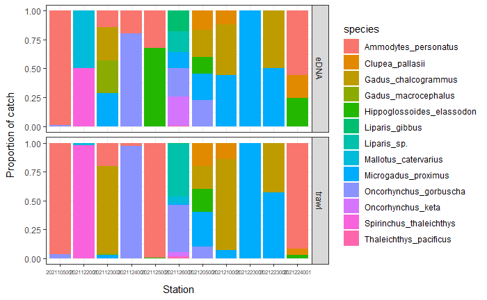

```r
catch.eDNA.merged %>%
  filter(station_number == station_number.1) %>%
  ggplot() +
  geom_bar(aes(x = station_number, y = prop_of_catch, fill = species), stat = "identity") +
  theme_bw() +
  facet_grid(rows = vars(gear_type)) +
  labs(
    y = "Proportion of catch",
    x = "Station"
  ) +
  theme(
    axis.text.x = element_text(size = 6),
    axis.title.x = element_text(margin = margin(t = 10)),
    axis.title.y = element_text(margin = margin(r = 10))
  )

ggsave("pdf_outputs/catch_comparison_eDNA_trawl.pdf", height = 4, width = 9)
```

Come up with a figure that compares the trawl to the eDNA catches

| station_number | common_name | species | genus_name | species_name | SumOfcount | family | station_number.1 | taxon | depth | mean_reads |
| --- | --- | --- | --- | --- | --- | --- | --- | --- | --- | --- |
| 2021105001 | Pacific sand lance | Ammodytes_personatus | Ammodytes | personatus | 200 | Ammodytidae | 2021105001 | Ammodytidae | 11 | 4655.200 |
| 2021105001 | Pink salmon (humpback) | Oncorhynchus_gorbuscha | Oncorhynchus | gorbuscha | 7 | Salmonidae | 2021105001 | Oncorhynchus | 11 | 45.500 |
| 2021122001 | Capelin | Mallotus_catervarius | Mallotus | catervarius | 2 | Osmeridae | 2021122001 | Osmeridae | 25 | 88.500 |
| 2021122001 | Longfin smelt | Spirinchus_thaleichthys | Spirinchus | thaleichthys | 103 | Osmeridae | 2021122001 | Osmeridae | 25 | 88.500 |
| 2021123001 | Pacific sand lance | Ammodytes_personatus | Ammodytes | personatus | 19 | Ammodytidae | 2021123001 | Ammodytidae | 30 | 3527.000 |
| 2021123001 | Pacific cod | Gadus_macrocephalus | Gadus | macrocephalus | 1 | Gadidae | 2021123001 | Gadidae | 30 | 6942.167 |
| 2021123001 | Pacific tomcod | Microgadus_proximus | Microgadus | proximus | 3 | Gadidae | 2021123001 | Gadidae | 30 | 6942.167 |
| 2021123001 | Walleye pollock | Gadus_chalcogrammus | Gadus | chalcogrammus | 72 | Gadidae | 2021123001 | Gadidae | 30 | 6942.167 |
| 2021124001 | Pacific sand lance | Ammodytes_personatus | Ammodytes | personatus | 1 | Ammodytidae | 2021124001 | Ammodytidae | 11 | 692.500 |
| 2021124001 | Pink salmon (humpback) | Oncorhynchus_gorbuscha | Oncorhynchus | gorbuscha | 35 | Salmonidae | 2021124001 | Oncorhynchus | 11 | 2781.400 |

[output cut: 33 more lines]

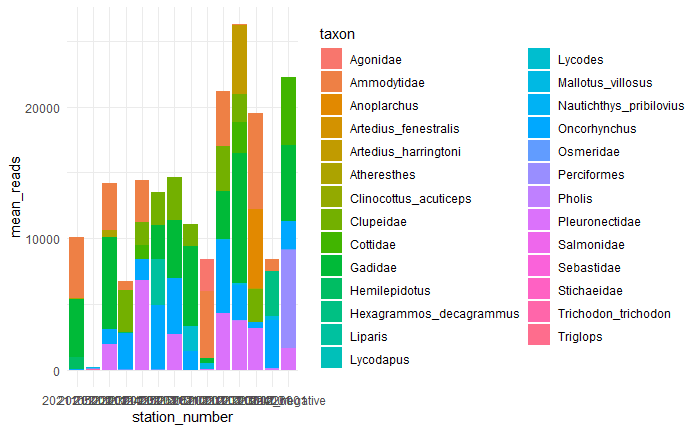

```r
cook.edna %>%
  ggplot(aes(x = station_number, y = mean_reads, fill = taxon)) +
  geom_bar(stat = "identity") +
  theme_minimal()
```

```r
NA
```